# Explorative analytics of users’ interactions with the prototype

## Load packages and data

```r
library(WRS2)
library(rcompanion)
library(feather)
library(ggplot2)
library(plyr)
library(ez)
library(schoRsch)
library(MASS)
library(car)
library(tidyverse)
library(ggpubr)
library(rstatix)
library(here)
```

Load the dataframe with users’ actions.

```r
df_useractions <- read_feather(path = here('../../data_frames/results_test_02-04-2020_user_actions.file'))
```

```
Coercing int64 to doubleCoercing int64 to doubleCoercing int64 to doubleCoercing int64 to doubleCoercing int64 to doubleCoercing int64 to doubleCoercing int64 to double
```

Load dataframe with the remaining experimental data in wide format.

```r
df_wide <- read_feather(path = here('../../data_frames/results_test_18-03-2020.file'))
```

```
Coercing int64 to doubleCoercing int64 to doubleCoercing int64 to doubleCoercing int64 to doubleCoercing int64 to doubleCoercing int64 to doubleCoercing int64 to doubleCoercing int64 to doubleCoercing int64 to doubleCoercing int64 to doubleCoercing int64 to double
```

## Prepare the data

### Assign participants to the experimental group

- version 1 and 2 –> control group
- version 3 und 4 –> experimental group context free
- version 5 und 6–> experimental group context sensitive

```r
df_wide$group <- ifelse((df_wide$version == 5 | df_wide$version == 6), 'context-sensitive experimental group', ifelse((df_wide$version == 1 | df_wide$version == 2), 'controlgroup', 'context-free experimental group'))
df_useractions$group <- ifelse((df_useractions$version == 5 | df_useractions$version == 6), 'context-sensitive experimental group', ifelse((df_useractions$version == 1 | df_useractions$version == 2), 'controlgroup', 'context-free experimental group'))
```

```r
# Convert trial, group and subject number to factors in each dataframe
df_useractions$trial <- factor(df_useractions$trial, levels = c("tutorial", "warm up", "trial 1", "trial 2", "trial 3"))
df_useractions$group <- factor(df_useractions$group)
df_useractions$partnr <- factor(df_useractions$partnr)
df_wide$group <- factor(df_wide$group)
df_wide$partnr <- factor(df_wide$partnr)
```

### Convert dfs

```r
# exclude interactions during tutorial and warm up
df_trial <- df_useractions[!(df_useractions$trial=="tutorial" | df_useractions$trial=="warm up"), ]
```

```r
# user actions for all trials, only experimental groups
df <- df_trial[!(df_trial$group=="controlgroup"), ]
```

```r
# aggregate total use for each function per trial
df$total_use <- rowSums(df[,c("add_note", "add_to_context", "highlights", "open_website_from_sidebar", "remove_activity", "remove_from_context", "remove_note")], na.rm = TRUE)
```

```r
# convert df to wide format
df_w <- pivot_wider(data = df,
                           id_cols = partnr,
                           names_from = trial,
                           values_from = c("add_note", "add_to_context", "highlights", "open_website_from_sidebar", "remove_activity", "remove_from_context", "total_use"))
```

```r
# aggregate total use for each function across trials
df_w$total_use <- rowSums(df_w[,c("total_use_trial 1", "total_use_trial 2", "total_use_trial 3")])
```

```r
# add performance measure
df_wide <- transform(df_wide, perf = mistakes_after_interruption / entries_after_interruption)
# merge user actions and other experimental data to one dataframe
df_use <- merge(df_wide[,c("partnr", "NASATLX_1", "NASATLX_2", "NASATLX_3", "NASATLX_4", "SUS", "TAEG", "group", "perf")], df_w, by="partnr")
```

## Analyse data

### Do participants who used the prototype more have different charactertistics?

### How often have participants used any feature of the prototype?

```r
table(df_use$total_use)
```

```
 0  1  4  8  9 11 13 14 15 16 17 18 19 20 21 22 23 24 25 27 29 30 48
 3  1  2  1  1  2  2  1  2  1  1  1  2  3  1  1  1  1  1  2  1  2  1
```

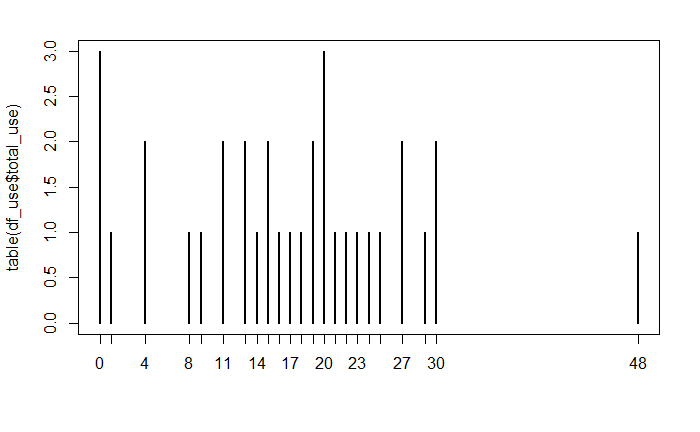

```r
plot(table(df_use$total_use))
```

```r
median(df_use$total_use)
```

```
[1] 17.5
```

```r
mean(df_use$total_use)
```

```
[1] 16.85294
```

Usage decreases over trials.

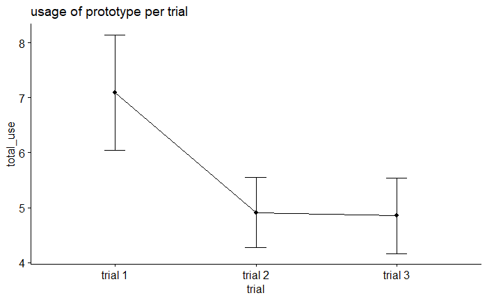

```r
ggline(df, x = "trial", y ="total_use",
       add = c("mean_se"),
       title = "usage of prototype per trial")
```

#### correlations with TA-EG, SUS and NASA-TLX

##### TA-EG (n.s.)

```r
cor.test(df_use$TAEG, df_use$total_use)
```

```
    Pearson's product-moment correlation

data:  df_use$TAEG and df_use$total_use
t = 0.76728, df = 32, p-value = 0.4485
alternative hypothesis: true correlation is not equal to 0
95 percent confidence interval:
 -0.2134615  0.4520268
sample estimates:
      cor
0.1344064
```

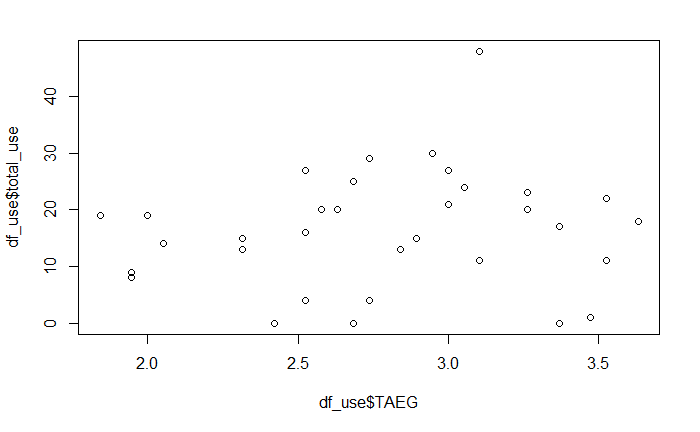

```r
plot(df_use$TAEG, df_use$total_use)
```

##### SUS (n.s.)

```r
cor.test(df_use$SUS, df_use$total_use)
```

```
    Pearson's product-moment correlation

data:  df_use$SUS and df_use$total_use
t = 1.8954, df = 32, p-value = 0.0671
alternative hypothesis: true correlation is not equal to 0
95 percent confidence interval:
 -0.02292707  0.59223974
sample estimates:
      cor
0.3177018
```

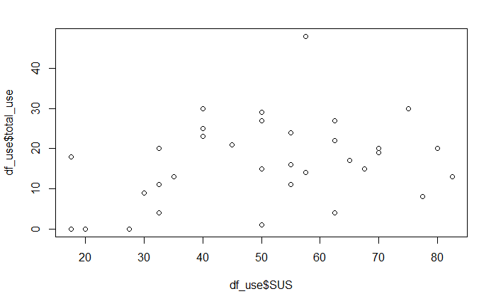

```r
plot(df_use$SUS, df_use$total_use)
```

##### NASA-TLX (n.s.)

```r
df_use$NASATLX_mean <- rowMeans(df_use[,c("NASATLX_1", "NASATLX_2", "NASATLX_3", "NASATLX_4")])
cor.test(df_use$NASATLX_mean, df_use$total_use)
```

```
    Pearson's product-moment correlation

data:  df_use$NASATLX_mean and df_use$total_use
t = -1.4852, df = 32, p-value = 0.1473
alternative hypothesis: true correlation is not equal to 0
95 percent confidence interval:
 -0.54528087  0.09213726
sample estimates:
       cor
-0.2539406
```

```r
cor.test(df_use$NASATLX_2, df_use$`total_use_trial 1`)
```

```
    Pearson's product-moment correlation

data:  df_use$NASATLX_2 and df_use$`total_use_trial 1`
t = -1.3327, df = 32, p-value = 0.1921
alternative hypothesis: true correlation is not equal to 0
95 percent confidence interval:
 -0.5266362  0.1180086
sample estimates:
      cor
-0.229308
```

```r
cor.test(df_use$NASATLX_3, df_use$`total_use_trial 2`)
```

```
    Pearson's product-moment correlation

data:  df_use$NASATLX_3 and df_use$`total_use_trial 2`
t = -1.0211, df = 32, p-value = 0.3148
alternative hypothesis: true correlation is not equal to 0
95 percent confidence interval:
 -0.4865781  0.1707826
sample estimates:
       cor
-0.1776424
```

```r
cor.test(df_use$NASATLX_4, df_use$`total_use_trial 3`)
```

```
    Pearson's product-moment correlation

data:  df_use$NASATLX_4 and df_use$`total_use_trial 3`
t = -0.86484, df = 32, p-value = 0.3936
alternative hypothesis: true correlation is not equal to 0
95 percent confidence interval:
 -0.4655029  0.1971120
sample estimates:
       cor
-0.1511273
```

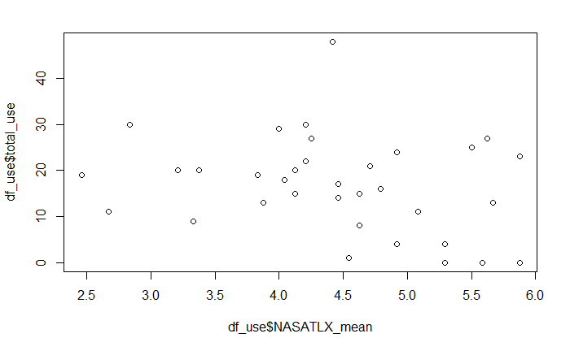

```r
plot(df_use$NASATLX_mean, df_use$total_use)
```

We compare participants who have not used the prototype in every trial vs. participants who have used the prototype at least once in every trial, as well as participants who have used the prototype more than average vs. less than average.

```r
#categorize participants
df_use$usage_every_trial <- ifelse((df_use$`total_use_trial 1` == 0 | df_use$`total_use_trial 2` == 0 | df_use$`total_use_trial 3` == 0), 0, 1)
df_use$usage_every_trial <- as.factor(df_use$usage_every_trial)
df_use$usage_above_average <- ifelse((df_use$total_use > 17), 1, 0)
df_use$usage_above_average <- as.factor(df_use$usage_above_average)
df_use %>%
  count(usage_every_trial)
```

| usage_every_trial | n |
| --- | --- |
| 0 | 8 |
| 1 | 26 |

There are only eight participants in the experimental groups who have not used the prototype at least once per trial.

#### TA-EG

There are no differences in participants’ TAEG values for participants with low versus high usage.

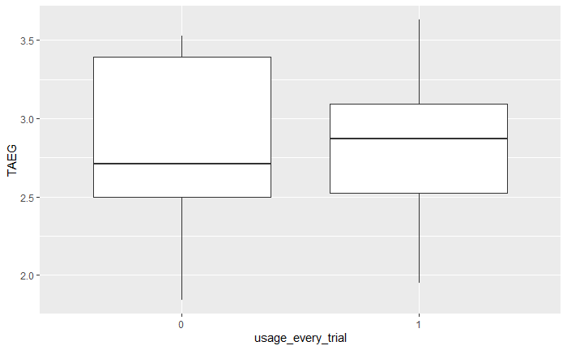

```r
par(mfrow = c(2,1))
ggplot(aes(y = TAEG, x = usage_every_trial), data = df_use) + geom_boxplot()
```

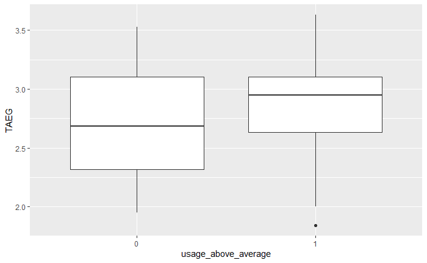

```r
ggplot(aes(y = TAEG, x = usage_above_average), data = df_use) + geom_boxplot()
```

```r
kruskal.test(df_use$TAEG, df_use$usage_every_trial)
```

```
    Kruskal-Wallis rank sum test

data:  df_use$TAEG and df_use$usage_every_trial
Kruskal-Wallis chi-squared = 0.014867, df = 1, p-value = 0.903
```

```r
kruskal.test(df_use$TAEG, df_use$usage_above_average)
```

```
    Kruskal-Wallis rank sum test

data:  df_use$TAEG and df_use$usage_above_average
Kruskal-Wallis chi-squared = 1.106, df = 1, p-value = 0.293
```

##### SUS

Trend: Participants who have used the prototype at least once in every trial gave it a more positive usability rating.

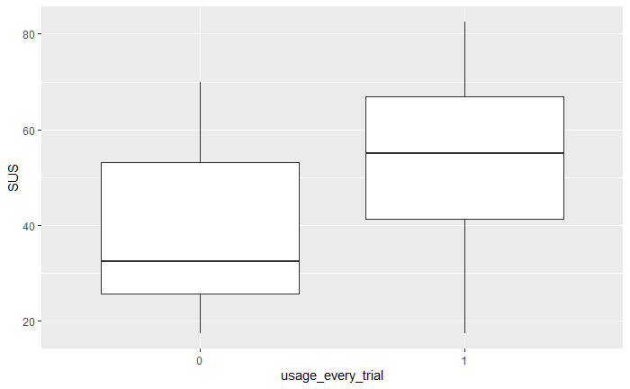

```r
ggplot(aes(y = SUS, x = usage_every_trial), data = df_use) + geom_boxplot()
```

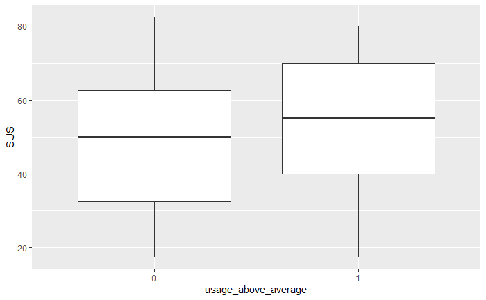

```r
ggplot(aes(y = SUS, x = usage_above_average), data = df_use) + geom_boxplot()
```

```r
kruskal.test(df_use$SUS, df_use$usage_every_trial)
```

```
    Kruskal-Wallis rank sum test

data:  df_use$SUS and df_use$usage_every_trial
Kruskal-Wallis chi-squared = 3.9771, df = 1, p-value = 0.04612
```

```r
kruskal.test(df_use$SUS, df_use$usage_above_average)
```

```
    Kruskal-Wallis rank sum test

data:  df_use$SUS and df_use$usage_above_average
Kruskal-Wallis chi-squared = 0.90159, df = 1, p-value = 0.3424
```

##### NASA-TLX

There is a trend that participants who used the prototype on every trial felt less workload. But there are only very few participants who did not use it every trial, so the results should be interpreted with care.

On the other hand, there is a trend that participants who use the prototype above average feel less workload (significant for the last trial).

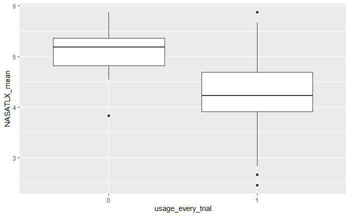

```r
ggplot(aes(y = NASATLX_mean, x = usage_every_trial), data = df_use) + geom_boxplot()
```

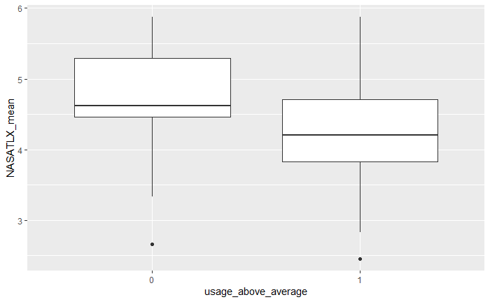

```r
ggplot(aes(y = NASATLX_mean, x = usage_above_average), data = df_use) + geom_boxplot()
```

```r
#significant
kruskal.test(df_use$NASATLX_mean, df_use$usage_every_trial)
```

```
    Kruskal-Wallis rank sum test

data:  df_use$NASATLX_mean and df_use$usage_every_trial
Kruskal-Wallis chi-squared = 5.0828, df = 1, p-value = 0.02416
```

```r
#n.s.
kruskal.test(df_use$NASATLX_mean, df_use$usage_above_average)
```

```
    Kruskal-Wallis rank sum test

data:  df_use$NASATLX_mean and df_use$usage_above_average
Kruskal-Wallis chi-squared = 2.7936, df = 1, p-value = 0.09464
```

for trial 0:

```r
## significant
kruskal.test(df_use$NASATLX_1, df_use$usage_every_trial)
```

```
    Kruskal-Wallis rank sum test

data:  df_use$NASATLX_1 and df_use$usage_every_trial
Kruskal-Wallis chi-squared = 5.5809, df = 1, p-value = 0.01816
```

```r
## n.s.
kruskal.test(df_use$NASATLX_1, df_use$usage_above_average)
```

```
    Kruskal-Wallis rank sum test

data:  df_use$NASATLX_1 and df_use$usage_above_average
Kruskal-Wallis chi-squared = 0.63164, df = 1, p-value = 0.4268
```

```r
## significant
kruskal.test(df_use$NASATLX_2, df_use$usage_every_trial)
```

```
    Kruskal-Wallis rank sum test

data:  df_use$NASATLX_2 and df_use$usage_every_trial
Kruskal-Wallis chi-squared = 4.2237, df = 1, p-value = 0.03986
```

```r
## n.s.
kruskal.test(df_use$NASATLX_2, df_use$usage_above_average)
```

```
    Kruskal-Wallis rank sum test

data:  df_use$NASATLX_2 and df_use$usage_above_average
Kruskal-Wallis chi-squared = 1.7668, df = 1, p-value = 0.1838
```

```r
## n.s.
kruskal.test(df_use$NASATLX_3, df_use$usage_every_trial)
```

```
    Kruskal-Wallis rank sum test

data:  df_use$NASATLX_3 and df_use$usage_every_trial
Kruskal-Wallis chi-squared = 3.5191, df = 1, p-value = 0.06067
```

```r
## n.s.
kruskal.test(df_use$NASATLX_3, df_use$usage_above_average)
```

```
    Kruskal-Wallis rank sum test

data:  df_use$NASATLX_3 and df_use$usage_above_average
Kruskal-Wallis chi-squared = 2.7578, df = 1, p-value = 0.09678
```

```r
## n.s.
kruskal.test(df_use$NASATLX_4, df_use$`total_use_trial 3`)
```

```
    Kruskal-Wallis rank sum test

data:  df_use$NASATLX_4 and df_use$`total_use_trial 3`
Kruskal-Wallis chi-squared = 9.5119, df = 12, p-value = 0.6587
```

```r
## significant
kruskal.test(df_use$NASATLX_4, df_use$usage_above_average)
```

```
    Kruskal-Wallis rank sum test

data:  df_use$NASATLX_4 and df_use$usage_above_average
Kruskal-Wallis chi-squared = 4.9567, df = 1, p-value = 0.02599
```

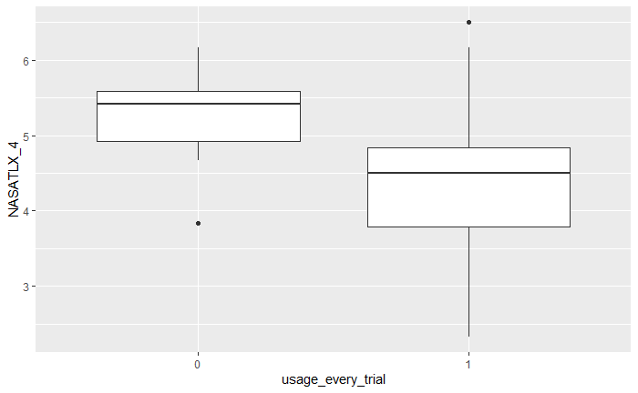

```r
ggplot(aes(y = NASATLX_4, x = usage_every_trial), data = df_use) + geom_boxplot()
```

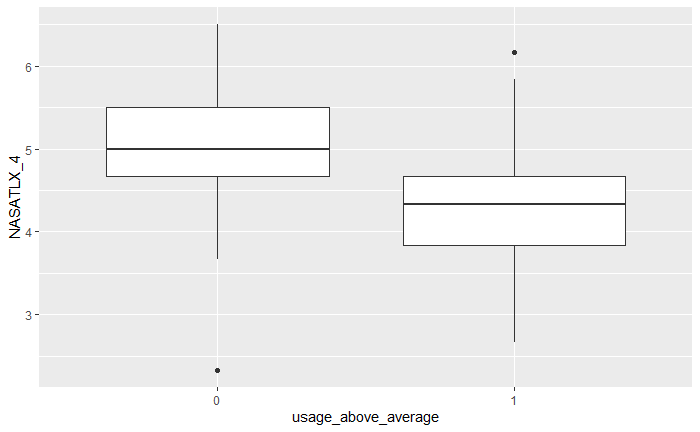

```r
ggplot(aes(y = NASATLX_4, x = usage_above_average), data = df_use) + geom_boxplot()
```

### Analysis of performance

There seem to be no differences for performance.

```r
exclude <- list(11, 26)
df_perf <- subset(df_use, !(df_use$partnr %in% exclude))
```

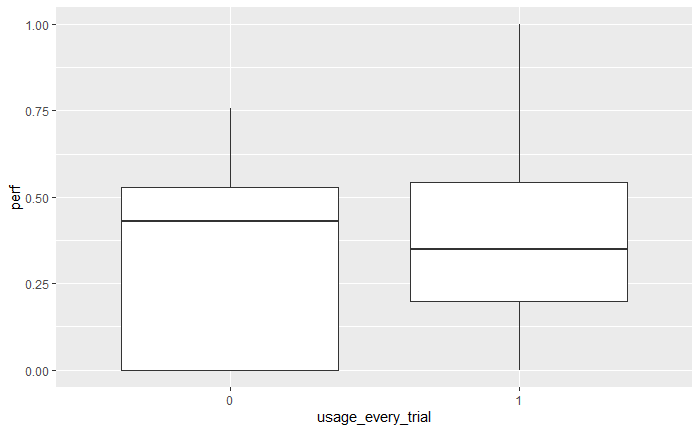

```r
ggplot(aes(y = perf, x = usage_every_trial), data = df_use) + geom_boxplot()
```

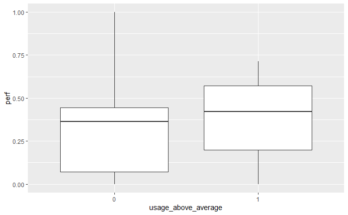

```r
ggplot(aes(y = perf, x = usage_above_average), data = df_use) + geom_boxplot()
```

```r
cor.test(df_perf$perf, df_perf$total_use)
```

```
    Pearson's product-moment correlation

data:  df_perf$perf and df_perf$total_use
t = 0.87513, df = 31, p-value = 0.3882
alternative hypothesis: true correlation is not equal to 0
95 percent confidence interval:
 -0.1986245  0.4733489
sample estimates:
      cor
0.1552725
```

```r
kruskal.test(df_perf$perf, df_perf$usage_every_trial)
```

```
    Kruskal-Wallis rank sum test

data:  df_perf$perf and df_perf$usage_every_trial
Kruskal-Wallis chi-squared = 0.40944, df = 1, p-value = 0.5223
```

```r
kruskal.test(df_perf$perf, df_perf$usage_above_average)
```

```
    Kruskal-Wallis rank sum test

data:  df_perf$perf and df_perf$usage_above_average
Kruskal-Wallis chi-squared = 1.2929, df = 1, p-value = 0.2555
```